title: “Problem Set 3 Explore One Variable”  
output: html_document  
===========================================

## Set up

Go to working directory Load the ggplot package

```r
#setwd("D:/DOCUMENTS/LEARNING/DAND/DAND4 EDA - R/PS3_One_Variable")
```

# PS3-1, QUIZ: DIAMONDS

### Load the diamonds data set in RStudio. As a reminder, you can use these

commands to load the diamonds data set. Some data sets come with R. You can load these data sets by typing `data(DATA_SET_NAME)`. The “diamonds” data set comes with the *ggplot* package.

```r
library(ggplot2)
data(diamonds)
```

You need to run these commands each time you launch RStudio to access the diamonds data set. RStudio won’t remember which packages and data sets you loaded unless you change your preferences or save your workspace.

You should notice that the diamonds data set will be listed as a ‘Promise’ in the workspace. *Promise* is a special object in R, and you need to run a command on the data to fully load the data set.

Try running a summary: `summary(diamonds)`

You can learn more about the diamonds data set by typing `?diamonds`

Read the help file to determine the best color for the diamonds data set. When you run `diamonds$color` you will notice that the levels of color are set as “D < E < F < …” This is an ordering of the colors.

**How many observations are in the data set?** `dim(diamonds)` or `?diamonds` # preferred

**How many variables are in the data set?** `dim(diamonds)` or `?diamonds` # preferred

**How many ordered factors are in the data set?** 3 `str(diamonds)`

__ What letter represents the best color for a diamond?__ I read the help file `?diamonds`

“color: diamond colour, from J (worst) to D (best)”

========================================================

# PS3-2, Price Histogram

Create a histogram of the price of all the diamonds in the diamond data set. TYPE YOUR CODE BELOW THE LINE  
——————————-

`qplot(x = price, data = diamonds)`

========================================================

# PS3-3, Price Histogram Summary

Describe the shape and center of the price distribution. Include summary statistics like the mean and median.

`summary(diamonds$price)`

========================================================

# PS3-4, Diamond Counts

__How many diamonds cost less that $500?__ `summary(diamonds$price < 500)` Mode FALSE TRUE NA’s logical 52211 1729 0

__How many diamonds cost less that $250?__ `summary(diamonds$price < 250)` Mode FALSE NA’s logical 53940 0

__How many diamonds cost $15,000 or more?__ `summary(diamonds$price >= 15000)` Mode FALSE TRUE NA’s logical 52284 1656 0

========================================================

# PS3-5, Cheaper Diamonds

Explore the largest peak in the price histogram you created earlier.

Try limiting the x-axis, altering the bin width, and setting different breaks on the x-axis.

Go to the discussions to share your thoughts and discover what other people find.

You can save images by using the `ggsave()` command. `ggsave()` will save the last plot created. For example… `qplot(x = price, data = diamonds)` `ggsave('priceHistogram.png')`

Submit your final code when you are ready.

TYPE YOUR CODE BELOW THE LINE —————————–

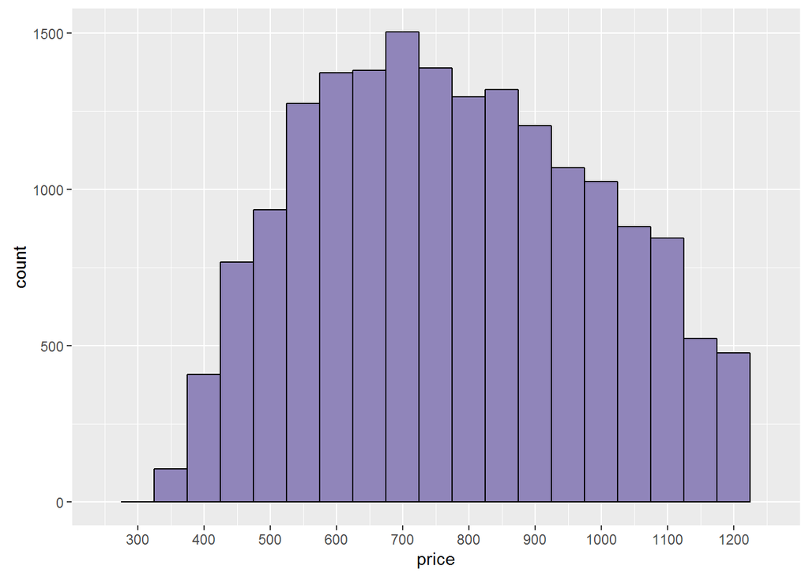

```r
# limit the x-axis, alter binwidth, set breaks
qplot(x = price, data = diamonds, binwidth = 50,
      color = I('black'), fill = I('#9085BA')) +
  scale_x_continuous(limits = c(250, 1250), breaks = seq(300, 1200, 100))
```

```r
ggsave('cheaperHistogram.png')
```

========================================================

# PS3-6, Price-by-Cut Histograms

Break up the histogram of diamond prices, by their “cut”. You should have five histograms in separate panels on your resulting plot.

TYPE YOUR CODE BELOW THE LINE —————————–

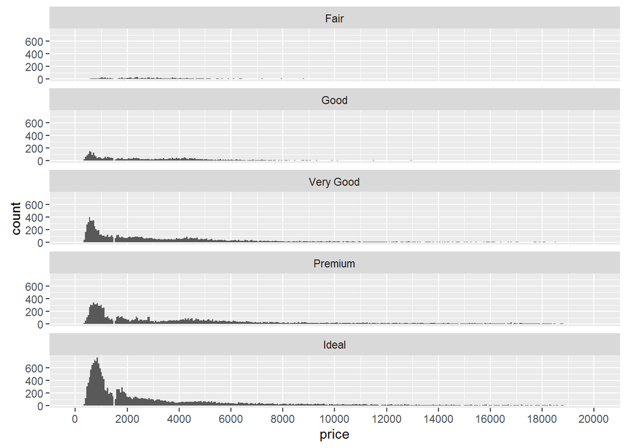

```r
qplot(x = price, data = diamonds, binwidth = 50) +
  scale_x_continuous(limits = c(0, 20000), breaks = seq(0, 20000, 2000)) +
  facet_wrap(~cut, ncol = 1)
```

========================================================

# PS3-7, Price-by-Cut

`summary(diamonds$price)` Min. 1st Qu. Median Mean 3rd Qu. Max. 326 950 2401 3933 5324 18820

Which cut has the highest priced diamond? `subset(diamonds, diamonds$price == max(diamonds$price))` carat cut color clarity depth table price x y  
z 27750 2.29 Premium I VS2 60.8 60 18823 8.5 8.47 5.16 Answer: “Premium”

Which cut has the lowest priced diamond? `subset(diamonds, diamonds$price == min(diamonds$price))` carat cut color clarity depth table price x y  
z 1 0.23 Ideal E SI2 61.5 55 326 3.95 3.98 2.43 2 0.21 Premium E SI1 59.8 61 326 3.89 3.84 2.31 Answer: “Premium” and “Ideal”

Which cut has the lowest median price? `by(diamonds$price, diamonds$cut, median)`# median price, by cut diamonds$cut: Fair [1] 3282 diamonds$cut: Good [1] 3050.5 diamonds$cut: VeryGood [1] 2648 diamonds$cut: Premium [1] 3185 diamonds$cut: Ideal [1] 1810 Answer: “Ideal”

*Note: Could also have answered all 3 questions by running the following code:* `by(diamonds$price, diamonds$cut, summary)` # summarize price, by cut

diamonds$cut: Fair Min. 1st Qu. Median Mean 3rd Qu. Max. 337 2050 3282 4359 5206 18570 diamonds$cut: Good Min. 1st Qu. Median Mean 3rd Qu. Max. 327 1145 3050 3929 5028 18790 diamonds$cut: Very Good Min. 1st Qu. Median Mean 3rd Qu. Max. 336 912 2648 3982 5373 18820 diamonds$cut: Premium Min. 1st Qu. Median Mean 3rd Qu. Max. 326  
1046 3185 4584 6296 18820 diamonds$cut: Ideal Min. 1st Qu. Median  
Mean 3rd Qu. Max. 326 878 1810 3458 4678 18810

========================================================

# PS3-8, Scales and Multiple Histograms

**How to display multiple plots with different y-axis scales**

In the previous exercise, we looked at the summary statistics for diamond price by cut.

In the output table, the median and quartiles are reasonably close to each other. This means the distributions should be somewhat similar, but the histograms we created don’t show that. The ‘Fair’ and ‘Good’ diamonds appear to have different distributions compared to the better cut diamonds. They seem somewhat uniform on the left with long tails on the right.

Let’s look in to this… Look up the documentation for `facet_wrap` in R Studio. Then, scroll back up and add a parameter to `facet_wrap` so that the y-axis in the histograms is not fixed. You want the y-axis to be different for each histogram.

If you want a hint, check out the Instructor Notes. ggplot2 Free scales with facets

ref: PS3-6 {r price by cut histo}

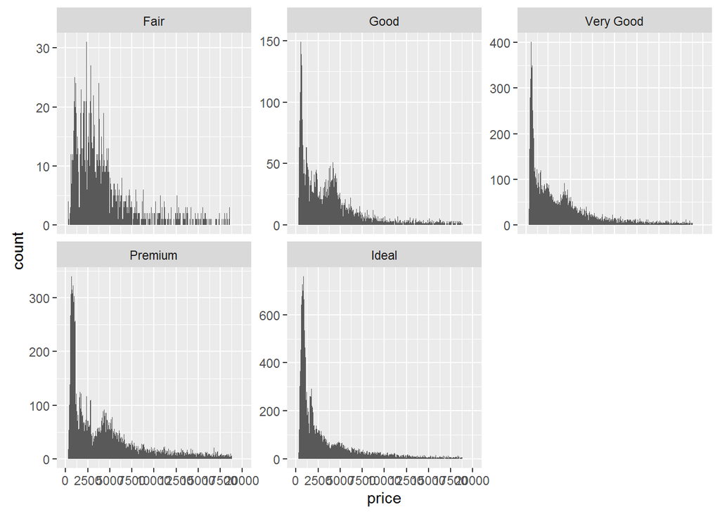

```r
ggplot(diamonds, aes(x=price)) + geom_histogram(binwidth = 50) +
  scale_x_continuous(limits = c(0, 20000), breaks = seq(0, 20000, 2500)) +
  facet_wrap(~cut, scales='free_y')
```

Grader response: Great Job! Are your y-axis scales different on some of the panels? It’s a good idea to consider the scales when you create plots.

========================================================

# PS3-9, Price per Carat by Cut

Create a histogram of price per carat and facet it by cut. You can make adjustments to the code from the previous exercise to get started.

Adjust the bin width and transform the scale of the x-axis using log10.

**Hints** Hint 1: You use the price and carat variables in the parameter for x. What expression gives you price per carat?

Hint 2: For long tailed distributions, you can add a ggplot layer such as `scale_x_log10()` to transform the variable.

ENTER YOUR CODE BELOW THIS LINE ——————————-

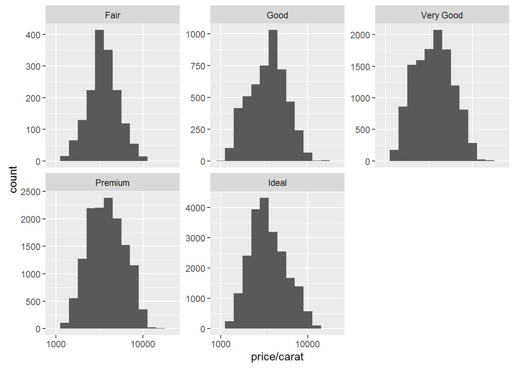

```r
qplot(x = price/carat, data = diamonds, binwidth = 0.1) +
  facet_wrap(~cut, scales='free_y') + scale_x_log10()
```

**Lessons Learned:** I learned in this problem that only a binwidth under 1.0 would produce a meaningful histogram. Sure it has somthing to do with logarithms, and also maybe logs combined with a fraction (price/carat)– *NAAHH*, probably just because its logs. But note, you’re only using a logarithmic scale because the plain histogram plots *had long tails*.

========================================================

# PS 3-10, Price Box Plots

Investigate the price of diamonds using box plots, numerical summaries, and one of the following categorical variables: cut, clarity, or color.

There won’t be a solution video for this exercise so go to the discussion thread for either BOXPLOTS BY CLARITY, *BOXPLOT BY COLOR*, or BOXPLOTS BY CUT to share you thoughts and to see what other people found.

**I chose PRICE and COLOR**

**Box Plots** HINT: For boxplots, we use – the *y* parameter for the *continuous* data – the *x* parameter for the *categorical* data

*Very useful, relevant link!:* [Boxplots are ideally suited for visualizing data variability](http://bxhorn.com/ggplot-boxplots/)

and maybe, “http://www.cookbook-r.com/Graphs/Plotting_distributions_(ggplot2)/#box-plots” and maybe, “http://www.statmethods.net/graphs/boxplot.html”

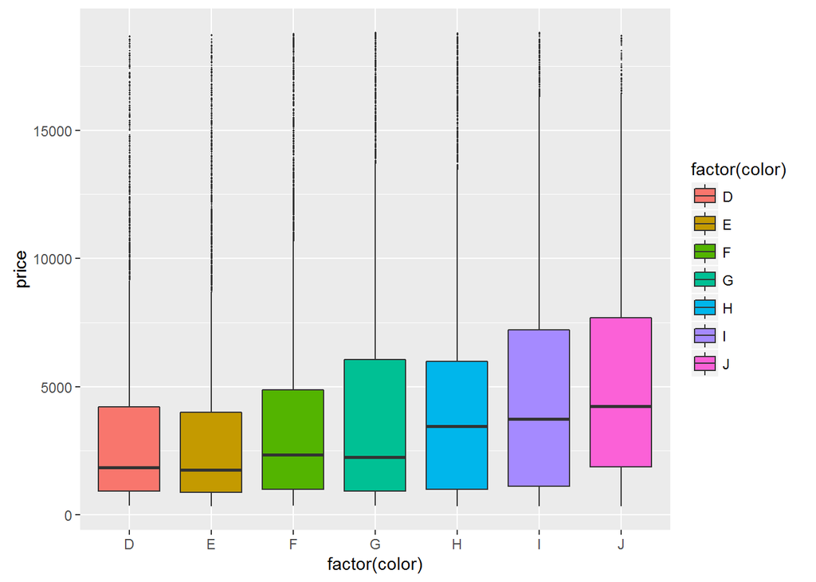

```r
ggplot(diamonds, aes(x=factor(color), y=price)) +
  geom_boxplot(aes(fill=factor(color)), outlier.size = 0.2)
```

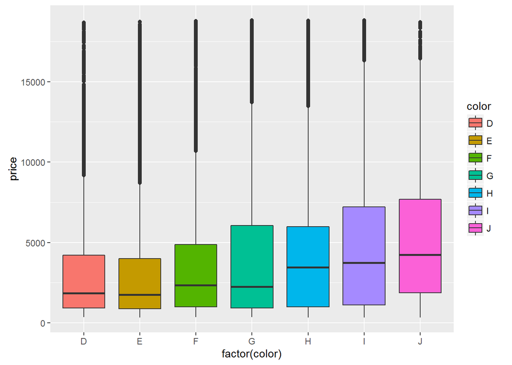

```r
ggsave('3-10_ggboxplot_smalldot-outliers.png')
qplot(x=factor(color), y=price, data=diamonds, geom='boxplot', fill=color)
```

```r
ggsave('3-10_qplot_box_colored.png')
```

Mark a spot at the mean (see cookbook-r.com reference, above)

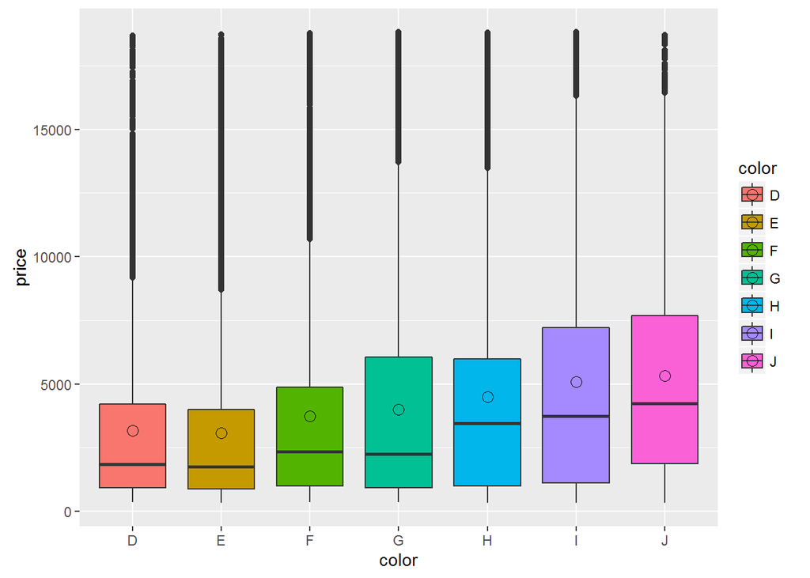

```r
qplot(x=color, y=price, data=diamonds, geom='boxplot',fill=color) +
  stat_summary(fun.y=mean, geom="point", shape=1, size=3)
```

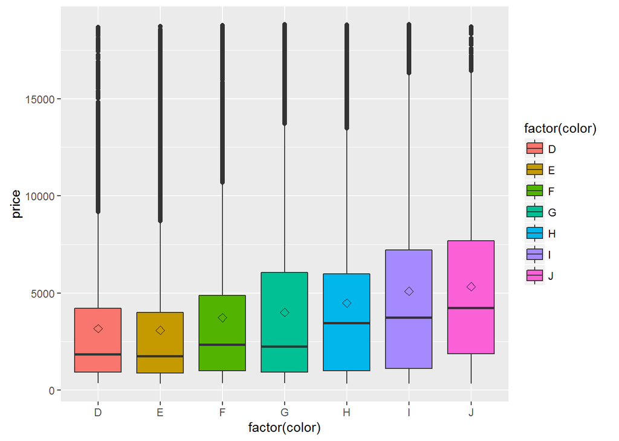

```r
ggsave('3-10_qplot_box_with_mean.png')
ggplot(diamonds, aes(x=factor(color), y=price)) +
  geom_boxplot(aes(fill=factor(color))) +
  stat_summary(fun.y=mean, geom="point", shape=5, size=2)
```

```r
table(diamonds$color) # count of observations by color
```

```
##
##     D     E     F     G     H     I     J
##  6775  9797  9542 11292  8304  5422  2808
```

```r
by(diamonds$price, diamonds$color, summary) # summarize price by color
```

```
## diamonds$color: D
##    Min. 1st Qu.  Median    Mean 3rd Qu.    Max.
##     357     911    1838    3170    4214   18690
## --------------------------------------------------------
## diamonds$color: E
##    Min. 1st Qu.  Median    Mean 3rd Qu.    Max.
##     326     882    1739    3077    4003   18730
## --------------------------------------------------------
## diamonds$color: F
##    Min. 1st Qu.  Median    Mean 3rd Qu.    Max.
##     342     982    2344    3725    4868   18790
## --------------------------------------------------------
## diamonds$color: G
##    Min. 1st Qu.  Median    Mean 3rd Qu.    Max.
##     354     931    2242    3999    6048   18820
## --------------------------------------------------------
## diamonds$color: H
##    Min. 1st Qu.  Median    Mean 3rd Qu.    Max.
##     337     984    3460    4487    5980   18800
## --------------------------------------------------------
## diamonds$color: I
##    Min. 1st Qu.  Median    Mean 3rd Qu.    Max.
##     334    1120    3730    5092    7202   18820
## --------------------------------------------------------
## diamonds$color: J
##    Min. 1st Qu.  Median    Mean 3rd Qu.    Max.
##     335    1860    4234    5324    7695   18710
```

**My Comments:** Min and Max prices hardly vary between colors. All of them are more dispersed in the “high” half of prices (above median), but particularly D-G. Less price Variance in better (D-F) colors and more variance in worse colors (G-J.) Yet the better colors have more outliers; that might pull their means higher; see marked-mean plots.

========================================================

# PS 3-11, Interquartile Range - IQR

You can use the function `IQR()` to find the interquartile range. Pass it a subset of the diamonds data frame.

For example… `IQR(subset(diamonds, price <1000)$price)`

Remember, `subset` returns a *data frame*, so we need to use $price on the end to access that variable.

range of middle 50% of color D diamonds?  
`by(diamonds$price, diamonds$color=='D', summary)`  
Look at the TRUE line returned.

Price range of middle 50% of color J diamonds? `by(diamonds$price, diamonds$color=='J', summary)` Look at the TRUE line returned.

IQR of diamonds with the best color? `IQR(subset(diamonds, color=='D')$price)`

IQR of diamonds with the worst color? `IQR(subset(diamonds, color=='J')$price)` - - - - - - - - - - - - - - - - - - - -

alternately, IQR of all each and every color: `by(diamonds$price, diamonds$color, IQR)`

========================================================

# PS 3-12, Price per Carat Box Plots by Color

Investigate the price per carat of diamonds across the different colors of diamonds using *boxplots*.

Save images by using the ggsave() command.

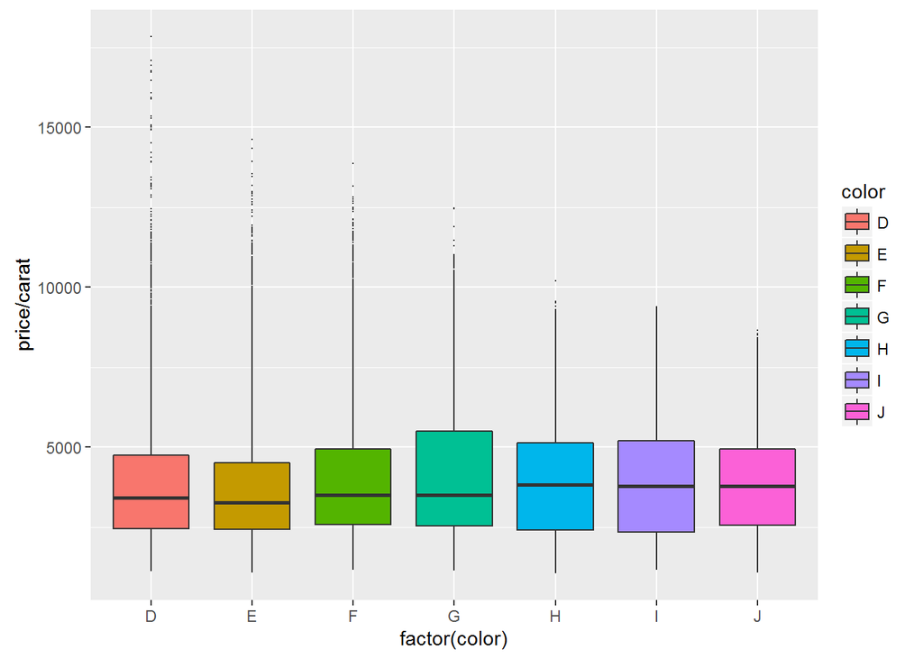

```r
qplot(x=factor(color), y = price/carat, data=diamonds,
      geom='boxplot', fill=color, outlier.size = 0.1)
```

```r
ggsave('3-12_ppcarat_by_color_boxplots.png')
```

========================================================

# PS 3-13 Carat Frequency Polygon

Investigate the weight of the diamonds (carat) using a frequency polygon. Use different bin widths to see how the frequency polygon changes. What carat size has a count greater than 2000?

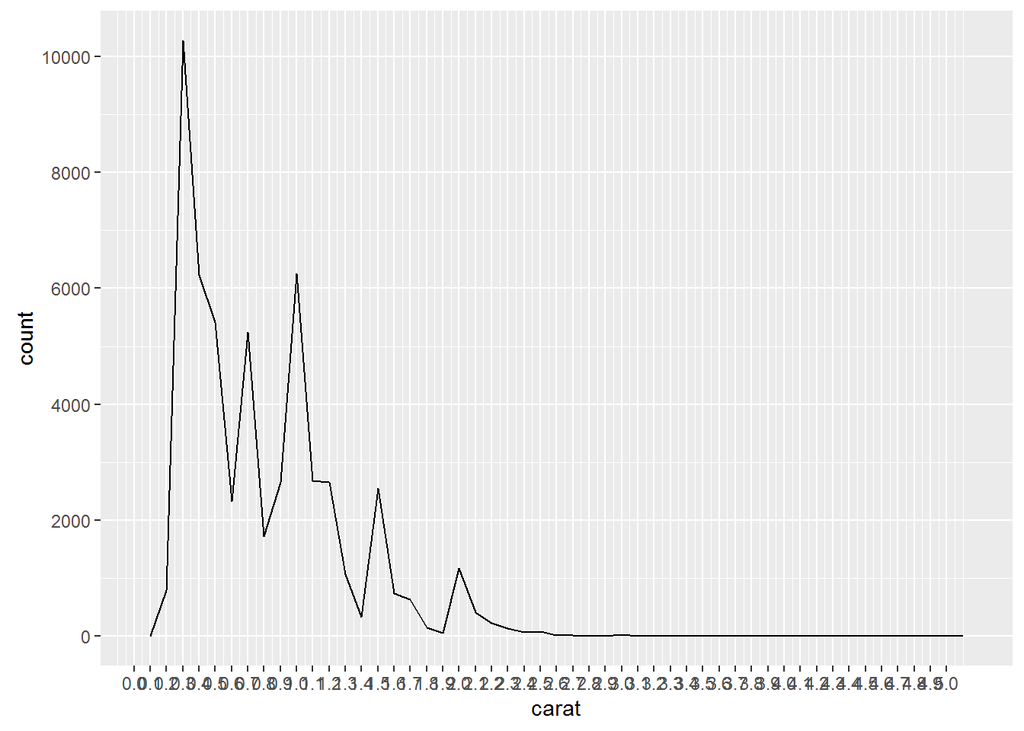

```r
qplot(x=carat, data=diamonds, binwidth=0.1, geom='freqpoly') +
scale_x_continuous(breaks=seq(0, 5.0, 0.1)) +
  scale_y_continuous(breaks = seq(0, 10000, 2000))
```

For the question, we are looking for counts of exact value - try starting out with a larger bin width and making it smaller to see how the plot changes, then focus in on the values of most interest.

**Lessons Learned:** Dealing with **continuous** data on the x-axis in a *frequency polygon* lets you assign a **binwidth less than 1**. I’d still been thinking in terms of *discrete* bin counts as in a bar plot.

========================================================

# PS 3-15, Gapminder Data quiz

The Gapminder website contains over 500 data sets with information about the world’s population. You can find a link to the Gapminder website in the Instructor Notes.

Your task is to download a data set of your choice and create 2-5 plots that make use of the techniques from Lesson 3.

You might use a **simple histogram**, a **boxplot split over a categorical variable**, or a **frequency polygon**. The choice is yours! Once you’ve completed your investigation, create a post in the discussions that includes: 1. any questions you answered, your observations, and summary statistics  
2. snippets of code that created the plots  
3. links to the images of your plots

You can save images by using the ggsave() command.

**Hints**  
The following command may be helpful for some of the Gapminder Data sets, once it’s been converted to csv format:  
`read.csv('data.csv', header = T, row.names = 1, check.names = F)`

You may want to look at additional function arguments in the help file for the `read.table()` family for additional tools that can help you read in data.

If you want to exchange the rows and columns of your dataframe, it will also be useful to know the transpose function, t().

## Copy and paste all of the code that you used for your investigation, and submit it when you are ready

========================================================

# PS 3-16, Exploring Friends’ Birthdays

Your task is to investigate the distribution of your friends’ birth months and days.

Here some questions you could answer, and we hope you think of others.

**How many people share your birthday? Do you know them?** **Which month contains the most number of birthdays?** **How many birthdays are in each month?** **Which day of the year has the most number of birthdays?** **Do you have at least 365 friends that have birthdays on every day of the year?**

You’ll need to export the birthdays to a csv file (or use the csv file we’ve provided a link to in the Instructor Notes)

Once you load the data into R Studio, you can use the `strptime()` function to extract the birth months and birth days. We recommend looking up the documentation for the function and finding examples online.

```r
# Import the data file
tb <- read.csv('birthdaysExample.csv')

# tb$dates is a factor, and when I try to convert it to date it converts all
# values to NA; so, try to convert from factor to vector of characters
tb$dates <- as.character(tb$dates)

# Convert to date format
tb$monthDay <- as.Date(tb$dates, format = "%m/%d")

# Month column
tb$month <- as.numeric(format(tb$monthDay, format = '%m'))

# Day column
tb$day <- as.numeric(format(tb$monthDay, format = '%d'))

# Count my birthday
myBday <- ifelse(tb$dates == '5/23/14', 1, 0)
sum(myBday)
```

```
## [1] 3
```

Month with most birthdays?

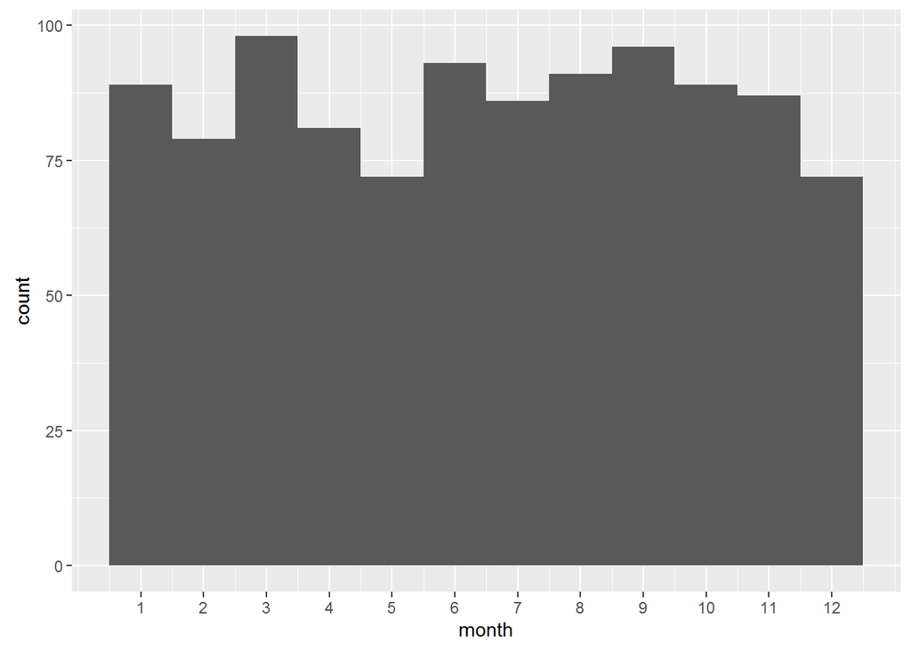

```r
qplot(x = month, data = tb, binwidth = 1) +
  scale_x_continuous(breaks = seq(1, 12, 1))
```

Answer: March

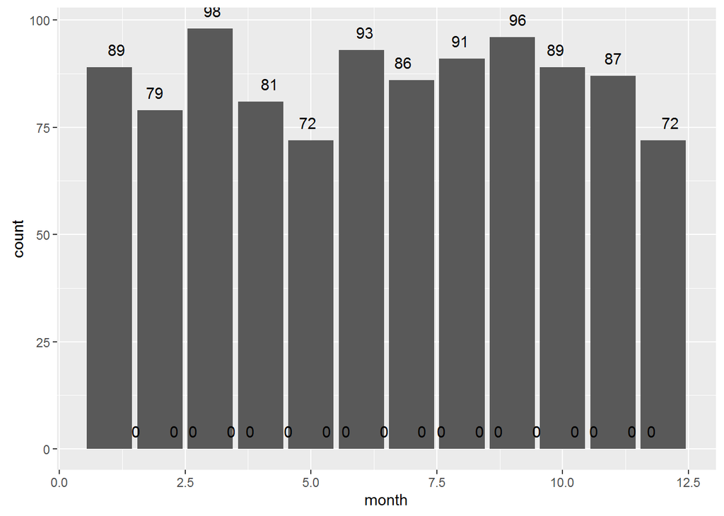

```r
ggplot(tb, aes(x=month), labels = ..count..) +
  geom_bar() +
  stat_bin(geom="text", aes(label=..count.., vjust=-1))
```

```r
ggsave('birthdays per month.png')
```

```r
datefreq <- data.frame(table(tb$monthDay))
datefreq[which.max(datefreq$Freq), ]
```

```
##          Var1 Freq
## 37 2016-02-06    8
```

[output not shown]

37 2016-02-06 8

Answer: February 6th.